# PG11: A Crash Course in Microbiome Analysis

## 4.2 Hypothesis testing

Next we’ll explore how to conduct significance testing.

### 4.2.1 PERMANOVA (adonis2)

The following is an example of a PERMANOVA implementation using `vegan::adonis2()`, comparing lung specimens by vendor. We find a significant difference between these groups, consistent with prior visual exploration.

```r
set.seed(rnd_seed) # setting a seed allows for reproducibility. Both of these lines need to be run together for it to work as expected.
# The left hand side of the formula is the transformed data, and the right hand side is a vector (column) container the group identifiers of interest.
# adonis(otu_lung_hel~otu_lung_df$vendor, method="euclidean", permutations = 10000)$aov.tab # 9.999e-05 *** # Note that adonis() will soon be deprecated
adonis2(otu_lung_hel~otu_lung_df$vendor, method="euclidean", permutations = 10000) # 9.999e-05 ***
```

|  | Df | SumOfSqs | R2 | F | Pr(>F) |
| --- | --- | --- | --- | --- | --- |
| otu_lung_df$vendor | 1 | 3.175407 | 0.09978694 | 4.212229 | 9.999e-05 |
| Residual | 38 | 28.646460 | 0.90021306 | NA | NA |
| Total | 39 | 31.821867 | 1.00000000 | NA | NA |

### 4.2.2 mvabund

Because this may take some time to finish (about 4.5 minutes on a powerful machine), the following code is commented out to prevent it slowing down the creation (knitting) of our report. To run this section at a future point that’s convenient for you, begin by simply highlighting all of the lines in the code chunk and then using **CTRL + Shift + C** (Windows) or **Shift + Command + C** (Mac) to uncomment the code. For code chunks that take a while to execute, whether due to statistical analyses or visualizations, it may be beneficial to set the code chunk `cache` parameter to `TRUE`. This will enable you to recreate your report much more quickly when making small changes elsewhere.

```r
# a <- Sys.time() # Sometimes this can take a while, so it might be useful to keep track of the time with start/stop points to allow us to compute the duration.
# otu_mva <- mvabund(otu_lung_df[,str_which(colnames(otu_lung_df), "Otu")]) # select only lung specimens and Otu columns
# otu_ven_many <- manyglm(otu_mva ~ otu_lung_df$vendor)
# otu_mva_results <- anova(otu_ven_many, p.uni="adjusted")
# b <- Sys.time()
# b - a
#
# plot(otu_ven_many) # Residual plot
# otu_mva_results$table # Signif
#
# # Example output
# # Analysis of Deviance Table
# #
# # Model: manyglm(formula = otu_mva ~ otu_lung$vendor)
# #
# # Multivariate test:
# #                 Res.Df Df.diff   Dev Pr(>Dev)
# # (Intercept)         39
# # otu_lung$vendor     38       1 797.9    0.001 ***
# # ---
# # Signif. codes:  0 ‘***’ 0.001 ‘**’ 0.01 ‘*’ 0.05 ‘.’ 0.1 ‘ ’ 1
```

### 4.2.3 Constrained Ordination: Redundancy Analysis

The following is an example using `vegan::rda()` on the `Cage` variable. For examples of CCA (correspondence analysis) and other ordination techniques, check out the [Intro to Vegan](https://cran.r-project.org/web/packages/vegan/vignettes/intro-vegan.pdf).

```r
# Run RDA on our hellinger transformed data. We'll need to pass in one or more vectors of metadata corresponding to the constraining variables.
lung_meta <- dplyr::filter(otu_df, specimen %in% rownames(otu_lung_df)) %>%
  dplyr::select(-str_which(colnames(otu_df), "Otu"))
cage_rda <- rda(otu_lung_hel ~ lung_meta$cage) # First create the rda model object
anova(cage_rda) # Analyze the model
```

|  | Df | Variance | F | Pr(>F) |
| --- | --- | --- | --- | --- |
| Model | 7 | 0.2607439 | 2.146919 | 0.001 |
| Residual | 32 | 0.5552014 | NA | NA |

# V. Relative Abundance of Key Community Members

Next we’ll further explore the influence of key OTUs and Families.

## 5.1 Identifying enriched taxonomic groups

### 5.1.1 mvabund

While we could make use of mvabund results if the prior mvabund code chunk was run, then examine whether there are any significant taxa, for time considerations we’ll show only the code to do so.

```r
# # The following lines could be run with an mvabund model
# # Restructure, sort, filter to retrieve significant OTUs
# otu_ven_sigpvals <- data.frame(OTU = colnames(otu_mva_results$uni.p), uni_p = otu_mva_results$uni.p[2,]) %>%
#   dplyr::filter(uni_p <= .05) %>% # The threshold here can be adjusted to the desired level.
#   droplevels() %>%
#   arrange(uni_p) # Orders the pvalues
#
# # label OTUS - Note that the OTU column is not a factor in this case
# otu_ven_sigpvals$OTU <- fct_inorder(paste0(otu_good_taxonomy[otu_ven_sigpvals$OTU, ]$Genus, " (", otu_ven_sigpvals$OTU, ")"))
# otu_ven_sigpvals
#
# # Example output (unformatted)
# #     OTU                             uni_p
# #     <fctr>                          <dbl>
# # Otu00002    Streptococcus (Otu00002)    0.001
# # Otu00025    unclassified (Otu00025) 0.001
# # Otu00041    Lactobacillus (Otu00041)    0.017
# # Otu00085    unclassified (Otu00085) 0.018
# # Otu00102    unclassified (Otu00102) 0.021
# # Otu00092    unclassified (Otu00092) 0.022
```

Here is an example of formatting a dataframe (in this case containing pvalues) for display in a report. See **Section VII** for additional details related to reporting.

```r
# Note that this is an example constructed for illustration purposes only
mva_sigpvals <- data.frame(Family = c("Lachnospiraceae", "Erysipelotrichaceae", "Porphyromonadaceae", "Clostridiaceae_1", "Streptococcaceae", "Lactobacillaceae"), uni_p = c(0.001, 0.003, 0.015, 0.016, 0.017, 0.017))
knitr::kable(mva_sigpvals, caption = "Vendors, Significant OTUs (.05)", align = "l") # Check out ?kable for further specifications.
```

Vendors, Significant OTUs (.05)

| Family | uni_p |
| --- | --- |
| Lachnospiraceae | 0.001 |
| Erysipelotrichaceae | 0.003 |
| Porphyromonadaceae | 0.015 |
| Clostridiaceae_1 | 0.016 |
| Streptococcaceae | 0.017 |
| Lactobacillaceae | 0.017 |

```r
# mva_sigpvals # default RStudio output

# # This example would use the output from previous code chunk rather than our arbitrary dataframe
# knitr::kable(otu_ven_sigpvals, caption = "Vendors, Significant OTUs (.05)", align = "l")
```

### 5.1.2 Random forest

Though random forests can be used for prediction, we’re especially interested in their feature importance scores. One of the strengths of random forests is that they perform well at handling many correlated features (as is true in the microbiome), as well as a mix of feature types.

#### 5.1.2.a Classification

Note: The importance metric used depends on whether we’re using a regression or classification random forest model. A generic variable importance plot is shown for one iteration of the model. For classification as shown below, we prefer to use MeanDecreaseAccuracy as our feature importance metric rather than MeanDecreaseGini, due to increased bias in the latter.

```r
# Aggregate the OTU data into family. This requires a fair amount of data reshaping and joining operations. Wrapping these steps into a function is ideal to avoid to retracing every step for simply changing a taxonomic level for aggregation (e.g. Phylum vs Family).
fam_df <- otu_df %>%
  dplyr::select(specimen, contains("Otu")) %>% # Keep only the specimen identifier and OTU columns
  tidyr::pivot_longer(cols = -stringr::str_which(colnames(.), "Otu", negate = TRUE), names_to = "OTU", values_to = "Percentage") %>% # Take data into long form in preparation for join operation
  dplyr::inner_join(dplyr::select(otu_good_taxonomy, OTU, Family), by = "OTU") %>% # Determine which columns to join from taxonomy table. Here we're adding the Family column.
  dplyr::group_by(specimen, Family) %>%
  dplyr::summarize(Percentage = sum(Percentage), .groups = "drop") %>% # Note that this step removes any metadata columns which aren't part of the grouping
  tidyr::spread(key = Family, value = Percentage) %>% # Return data from long form to wide
  dplyr::inner_join(dplyr::select(otu_df, -contains("Otu")), by = "specimen") %>%
  dplyr::select(specimen, reagent_tissue:IL1a, everything()) # Pull metadata columns to the front, all Family columns follow afterwards
```

Next, we’ll run a basic `randomForest`.

```r
# For lung specimens, retain only vendor & OTU columns
rf_df <- dplyr::filter(fam_df, tissue_type == "Lung") %>%
  dplyr::select(vendor, levels(otu_good_taxonomy$Family)) %>%
  droplevels()

a <- Sys.time()
set.seed(rnd_seed) # seed for reproducibility
# Setting the importance parameter to TRUE allows us to obtain the variable importance info we're interested in.
rf_vendors <- randomForest(vendor ~ ., data = rf_df, importance = TRUE)
b <- Sys.time()
b-a
```

```
## Time difference of 0.04316092 secs
```

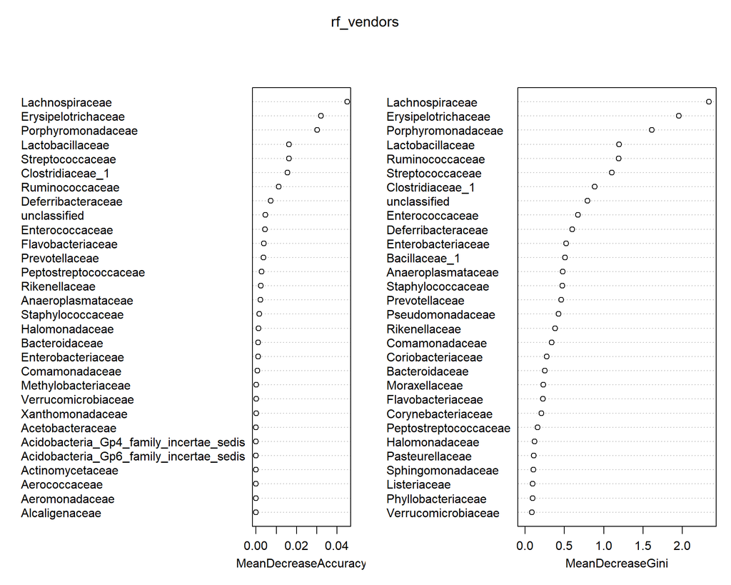

```r
# Basic variable importance plot
varImpPlot(rf_vendors, scale = FALSE)
```

```r
a <- Sys.time()
nforest <- 100
set.seed(rnd_seed) # seed for reproducibility
rf_list <- vector("list", nforest) # Initialize a list to store the randomForests
for (i in seq_along(1:nforest)) { # Loops nforest number of times, creating a model and saving it into the list each time.
    rf_list[[i]] <- randomForest(vendor ~ ., data = rf_df, importance = TRUE)
}
b <- Sys.time()
b-a
```

```
## Time difference of 4.168392 secs
```

```r
# Extract the feature importances
fi_df <- purrr::map(rf_list, ~{.[["importance"]][, 3]}) %>% # 3 specified the index of the importance column (classification)
  unlist() %>%
  data.frame(Feature = names(.), MeanDecreaseAccuracy = .) # rename the FI column to MeanDecreaseAccuracy

meas <- colnames(fi_df)[2] # "MeanDecreaseAccuracy"

# Identify the top features
top_feat <- fi_df %>%
  dplyr::group_by(Feature) %>%
  summarize(`:=`(!!meas, mean(.data[[meas]])), .groups = "drop") %>%
  arrange(desc(.data[[meas]])) %>%
  head(20) %>% # Top 20 features
  droplevels()

# Retain only the top features
fi_df <- dplyr::filter(fi_df, Feature %in% top_feat$Feature) %>%
  droplevels()
fi_df$Feature <- forcats::fct_reorder(fi_df$Feature, fi_df[, 2], .fun = mean, .desc = TRUE)
```

Next we’ll create boxplots of the feature importances over the 100 random forests. From this visual exploration we can more confidently conclude Lachnospiraceae were among the top two most important features in this model. Although these features are ordered by mean importance, also note the degree of overlap of importance across features. Any features whose range includes 0 should likely be excluded from a discussion about microbial importance.

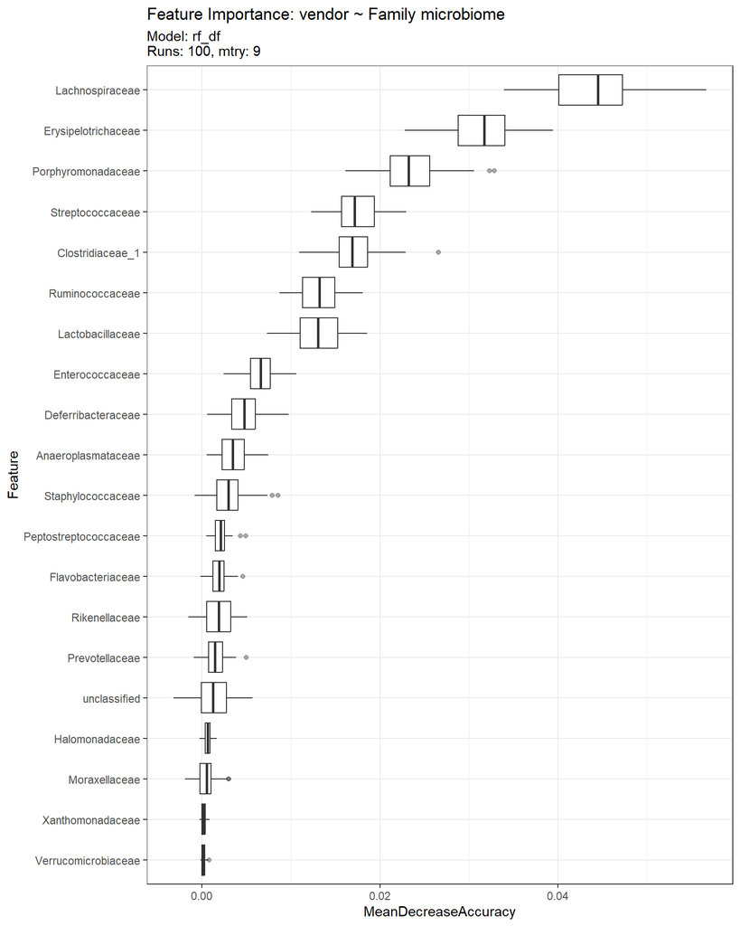

```r
ggplot(fi_df, aes(x = Feature, y = fi_df[, 2])) +
  geom_boxplot(outlier.alpha = 0.4) +
  theme_bw() +
  labs(y = meas, title = paste0("Feature Importance: vendor ~ Family microbiome"),
       subtitle = paste0("Model: rf_df \nRuns: ", length(rf_list), ", mtry: ", rf_list[[1]]$mtry)) +
  coord_flip() + # Flip the axes for improved readability
  scale_x_discrete(limits = rev(levels(fi_df$Feature)))
```

# VI. Community Diversity

In this section we’ll explore several measures of community diversity and examine how they can be used within our analyses.

## 6.1 α-diversity: within specimens

First, we’ll look at the diversity within specimens. We are interested in measures of:  
* **Richness** - how many unique taxa are there within a specimen?  
* **Evenness** - how evenly distributed are the taxa?  
* **Dominance** - what is the relative abundance of the dominant (largest %) taxa?

### 6.1.1 Shannon diversity & dominance

To measure α-diversity, we’ll compute the [Shannon diversity](https://en.wikipedia.org/wiki/Diversity_index) using the `diversity()` function, which calculates the Shannon index by default. Then we’ll select the observations of interest and compute summary statistics. The formula for deriving the Shannon index is shown below:

$$H' = -\sum_{i=1}^{R}p_{i} \ln
p_{i}$$

```r
# Create dataframe w/ Sample name, Shannon, Total Reads, Dominance on a per sample basis
alpha_div_df <- bind_cols(specimen = otu_df$specimen,
                          Shannon = diversity(otu_good), # Shannon diversity per specimen
                          Total_Reads = pmap_dbl(data.frame(otu_good),  sum), # rowwise sum (by specimen)
                          Dominance = pmap_dbl(dplyr::select(otu_df, contains("Otu")), max)) %>% # Dominance: max % of top OTU per specimen
  # mutate(Dominance = round(Dominance, 3)) # %>% # optional rounding; pipe(s) will need to be connected
  left_join(otu_df[,1:6], by = "specimen") # Join first 6 metadata columns, allows for easier filtering

shan_lung <- alpha_div_df %>%
  dplyr::filter(tissue_type == "Lung") %>% # Retain only lung specimens for visualization
  droplevels()

# Create Shannon diversity summary statistics for bars/error bars
agg_shan_lung <- shan_lung %>%
  group_by(vendor) %>%
  summarize(Mean_Sh = mean(Shannon), SEM_Sh = sqrt(var(Shannon)/length(Shannon)), .groups = "drop") # Create summary statistics
```

To visualize the results, we’ll plot the specimens’ α-diversities and means using `ggplot()`.

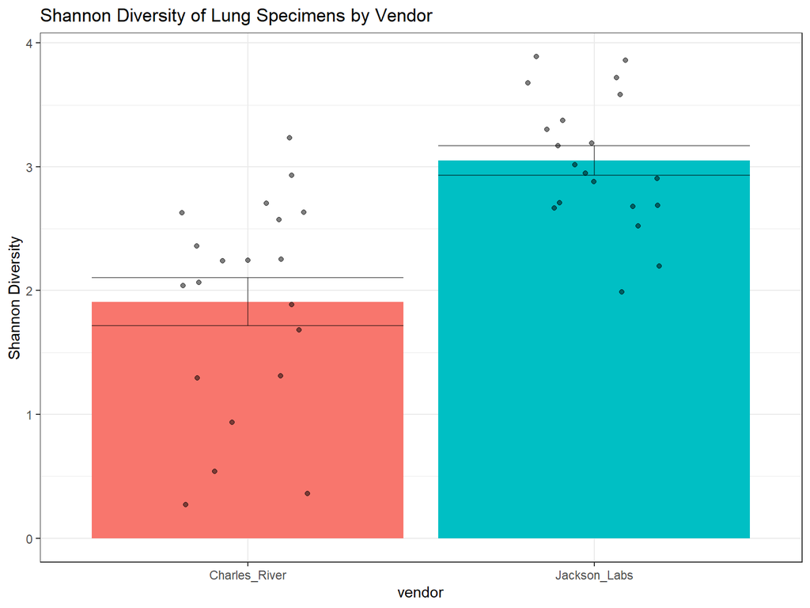

```r
ggplot(agg_shan_lung, aes(x = vendor, y = Mean_Sh, fill = vendor)) + # This brings in the aggregated dataframe and assigns columns to various plot elements
  geom_col(show.legend = FALSE) + # Add bars representing the mean of specimens' Shannon diversity by vendor
  geom_jitter(data = shan_lung, aes(x = vendor, y = Shannon), width = .2, alpha = .5, show.legend = FALSE) + # Use specimen level data, map columns to scatterplot attributes
  geom_errorbar(aes(ymin = Mean_Sh - SEM_Sh, ymax = Mean_Sh + SEM_Sh), alpha = .5) + # Add an errorbar layer
  theme_bw() + # A minimalist theme
  labs(y = "Shannon Diversity", title = "Shannon Diversity of Lung Specimens by Vendor") # Adjust axis label and title
```

We can also test the difference between the means of these groups for significance.

```r
# T-Test for the two vendors. This approach would also work if there were 3 or more groups.
TukeyHSD(aov(shan_lung$Shannon ~ shan_lung$vendor))
```

```
##   Tukey multiple comparisons of means
##     95% family-wise confidence level
##
## Fit: aov(formula = shan_lung$Shannon ~ shan_lung$vendor)
##
## $`shan_lung$vendor`
##                                diff       lwr      upr    p adj
## Jackson_Labs-Charles_River 1.139108 0.6790736 1.599143 1.28e-05
```

### 6.1.2 Rarefaction curves

Rarefaction curves can also be used to explore α-diversity. First, the data needs to be prepared.

```r
# Generate the rarefaction data, combine with metadata, transform for plotting, and aggregate
rarefy_agg <- rarefy(dplyr::select(otu_raw, -label, -numOtus), sample = 1:1000) %>% # subsample for each number in 1:1000; an alternative is to set sample = to the integer length of primary interest, e.g. 1000
  data.frame(row.names = rownames(otu_good)) %>% # Use cleaned up rownames from otu_good rather than messy names from otu_raw
  rownames_to_column("specimen") %>%
  pivot_longer(-specimen, names_to = "Sample_Seq_Num", names_prefix = "N", names_transform = list(Sample_Seq_Num = as.numeric), values_to = "Unique_Species") %>% # Transform data from long to wide format
  left_join(dplyr::select(otu_df, specimen, reagent_tissue, vendor, tissue_type), by = "specimen") %>%  # Join reagent_tissue, vendor, and tissue_type columns
  dplyr::filter((reagent_tissue == "Control") | (tissue_type == "Lung")) %>% # Keep only lung specimens and negative controls
  group_by(vendor, Sample_Seq_Num) %>%
  summarize(Mean_Species = mean(Unique_Species), SEM = sqrt(var(Unique_Species)/length(Unique_Species)), .groups = "drop") # Create summary statistics by vendor (negative controls are considered 'None')

# write.table(rarefy_raw,file = "rarefy.txt") # Output the table if desired
```

To visualize the rarefaction curves, we’ll use three `geom_line` layers as follows:

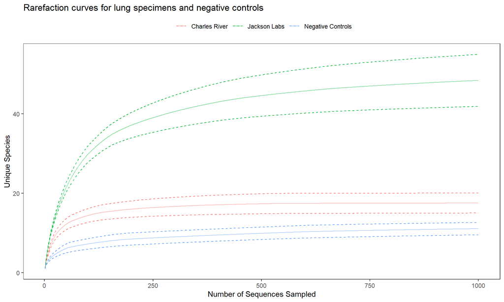

```r
ggplot(rarefy_agg, aes(x = Sample_Seq_Num, y = Mean_Species, color = vendor)) +
  geom_line(alpha = 0.5) + # Line for the mean
  geom_line(aes(y = Mean_Species - SEM), linetype = "dashed") + # Lower standard error
  geom_line(aes(y = Mean_Species + SEM), linetype = "dashed") + # Upper standard error
  theme_bw() +
  theme(panel.grid = element_blank(), legend.position = "top", legend.title = element_blank()) +
  scale_color_hue(labels = c("Charles River", "Jackson Labs", "Negative Controls")) + # Fix legend labels
  labs(x = "Number of Sequences Sampled", y = "Unique Species", title = "Rarefaction curves for lung specimens and negative controls")
```

### 6.1.3 Rank abundance plots

As we’ve already seen, RA plots can also be used as a means of exploring α-diversity.

## 6.2 𝛽-diversity: across specimens

Next we’ll examine diversity across specimens.

First, we revisit the PCA ordination of lung specimens by vendor to recall global dissimilarity between vendors:

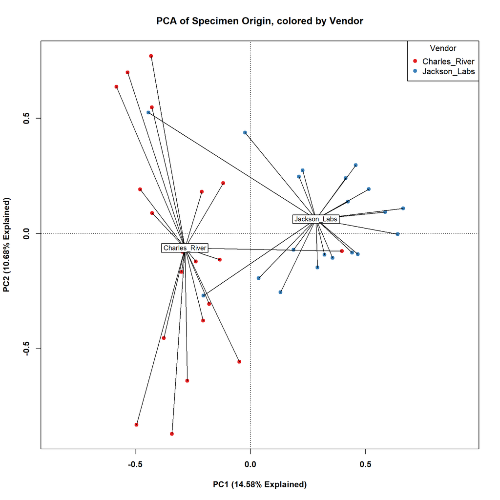

```r
# This approach combines base R plotting functionality and vegan's ordispider function, which creates the lines connecting points to the centroids.
# Unlike with ggplot(), these lines must all be run at once in order to produce the desired result.
plot(otu_lung_pca, type = "n", font = 2, font.lab = 2, xlab = "PC1 (14.58% Explained)", ylab = "PC2 (10.68% Explained)", main = "PCA of Specimen Origin, colored by Vendor", display = "sites")
points(otu_lung_pca, pch = 19, col = pcapal[as.numeric(otu_lung_df$vendor)]) # pch determines the point shape and col determines the colors to be used.
ordispider(otu_lung_pca, otu_lung_df$vendor, label = TRUE) # Draw lines from centroids to the points belonging to each group.
legend("topright", levels(otu_lung_df$vendor), pch = 19, col = pcapal, title = "Vendor") # Format and add details to legends
```

### 6.2.1 Bray-Curtis

[Bray-Curtis dissimilarity](https://en.wikipedia.org/wiki/Bray%E2%80%93Curtis_dissimilarity) is a statistic used to quantify the compositional dissimilarity between two different sites, based on counts at each site. A score of 1 represents complete dissimilarity between two specimens, meaning no OTUs are shared between the specimens. On the other hand, a score of 0 signifies complete similarity. The following formula provides the index of dissimilarity, though we’ll use `vegdist()` to handle computation:

$$BC_{IJ} = 1 - \frac{2C_{IJ}}{S_{i} +
S_{J}}$$

```r
# This helper function will be used to disambiguate columns associated with paired BC comparisons
# For example, the reagent_tissue for sample 1 could be different than sample 2, thus an identifier column
# might be necessary for each in order to filter the results as desired.
bc_rename <- function(colname) {
  if(str_detect(colname, ".x$")) { # For .x, simply remove the suffix
    return(str_remove(colname, ".x$"))
  } else if (str_detect(colname, ".y$")) {
    return(str_replace(colname, ".y$", "_comparison")) # For .y, replace with _comparison suffix
  } else { # Otherwise name does not need adjustment
    return(colname)
    }
}

# Goal: Full BC matrix converted to a long dataframe of all possible specimen comparisons.
# We could also add a step to filter for specimens of interest
sub_df <- otu_df %>% # First, subset to keep rows of interest for the Bray-Curtis comparisons
  dplyr::filter(reagent_tissue == "Tissue") %>% # Exclude controls
  droplevels()

bc_df <- sub_df %>%
  dplyr::select(contains("Otu")) %>% # retain OTU columns only
  vegan::vegdist(diag = TRUE, upper = TRUE) %>% # method = "bray" by default
  as.matrix() %>%
  as.data.frame(row.names = sub_df$specimen) %>%
  setNames(sub_df$specimen) %>% # add column names
  rownames_to_column("specimen") %>% # create specimen column from rownames
  pivot_longer(cols = -specimen, names_to = "comparison", values_to = "BC") %>% # transform from wide to long
  dplyr::filter(specimen != comparison) %>% # remove comparisons against the same specimen (the diagonal in the original distance matrix)
  left_join(dplyr::select(otu_df, specimen:tissue_type, cage), by = "specimen") %>% # join cols for subsetting by specimen1
  left_join(dplyr::select(otu_df, specimen:tissue_type, cage), by = c("comparison" = "specimen")) %>% # join cols for specimen2 (comparison)
  rename_with(~ map_chr(., bc_rename)) # use the custom renaming function defined above

# Here we'll subset to retain only the within vendor + tissue comparisons. We could also subset even further to group by `shipments` within vendors.
bc_tissue_vend_df <- bc_df %>%
  dplyr::filter(tissue_type == tissue_type_comparison, vendor == vendor_comparison) %>% # Comparisons of interest are within tissue + vendor groupings
  droplevels() %>%
  group_by(specimen, vendor, tissue_type) %>% # Carefully consider which variables to use for aggregation
  summarize(Mean_BC = mean(BC), SEM_BC = sqrt(var(BC)/length(BC)), .groups = "drop")
```

Next, plot within vendor tissue-tissue BC comparisons.

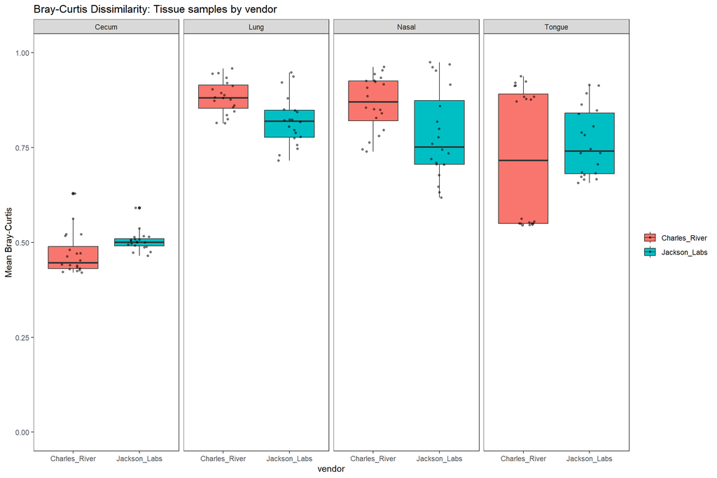

```r
ggplot(bc_tissue_vend_df, aes(x = vendor, y = Mean_BC, fill = vendor)) +
  geom_boxplot() + # alternatively, use a geom_col and an errorbar layer
  geom_point(size=1, alpha=0.5, position = position_jitter(width = 0.175, seed = rnd_seed)) + # add 'noisy' points for specimens (adjust width to improve visibility on discrete x-axis)
  theme_bw() + # A minimalist theme
  labs(y = "Mean Bray-Curtis", title = "Bray-Curtis Dissimilarity: Tissue samples by vendor") + # Adjust axis label and title
  facet_grid(. ~ tissue_type) +
  theme(panel.grid = element_blank(), legend.title = element_blank()) +
  expand_limits(y = c(0,1)) # Start y-axis at 0
```

# VII. Reporting

Usually it’s not enough to generate statistics or create visualizations. We also need to be able to share these results. Fortunately, there are a variety of ways to do this.

## 7.1 Exporting a dataframe

Here is an example of exporting `otu_lung` to a .csv file, which can then be opened in Excel or your spreadsheet editor of choice. Note that depending on your locale (whether , or ; is the expected separator), you may need to use `write.csv2()` to obtain the desired results. As an additional exercise, try changing the name of the dataframe or the name of the output file.

```r
# This will save a new file called otu_lung.csv in the current working directory
write_csv(otu_lung_df, "otu_lung.csv")
```

The following code chunk creates dataframes aggregated to various taxonomic levels and saves them as .csv files in the project directory. Bonus: instead of using the following loop to write these tables to files, they could be added to the global environment instead, for use in further analysis.

```r
# Create prep dataframe to use at each stage of taxonomic aggregation
taxa_prep_df <- otu_df %>%
  mutate(specimen = fct_inorder(specimen)) %>% # necessary to make specimen a factor to prevent alphabetic reordering in group_by + summarize operation
  dplyr::select(specimen, contains("Otu")) %>% # retains Specimen (or optionally adjust to Sample_name) and Otu cols
  pivot_longer(cols = -stringr::str_which(colnames(.), "Otu", negate = TRUE), names_to = "OTU", values_to = "Percentage") # wide to long transformation

# Create dataframes aggregated at the specified taxonomic levels
for(taxon in c("Phylum", "Class", "Order", "Family")) {
  taxa_prep_df %>% # Contains results of otu_good after decostand
    inner_join(dplyr::select(otu_good_taxonomy, OTU, all_of(taxon)), by = "OTU") %>% # join taxonomy table
    group_by(specimen, .data[[{taxon}]]) %>% # prepare to aggregate at specified taxonomic level
    summarize(Percentage = sum(Percentage), .groups = "drop") %>%
    spread(key = taxon, value = Percentage) %>% # transform to wide
    write_csv(paste0("CRJL_", tolower(taxon), "_table.csv")) # writes to .csv
    # Note, above line can commented and line below uncommented to add these dataframes to the global env
    # assign(x = paste0(substr(tolower(taxon), start = 1, stop = 3), "_df_ex"), pos = 1) # assigns values to df_names in curent environment (presumed to be global env)
    # Change the "_df_ex" if another naming scheme is preferred
}
```

## 7.2 Saving a plot

Next, we’ll save a plot. There are several methods for doing this and one approach utilizing `ggsave` is shown in the following code chunk.

Note that there will also be a figure-html folder (in this case: **PG11_Lung_Microbiome_Tutorial_files/figure-html/**) containing all of the plots created through the code chunks in this RMarkdown file. These are used in rendering the final report after finishing step 7.4, and these images could be retrieved from this folder after the knitting process is completed. If your report generates many figures, this might be a good way to go for non-reporting needs.

Additionally, while within `PG11_Lung_Microbiome_Tutorial.Rmd` and clicking ‘Show in New Window’ above a plot, then right clicking on the subsequent image displayed will bring up an option to save the image.

Yet another way to save a plot is to first save a plot to an object, for instance `p`, then type `p` followed by return in the console. Finally, navigate to the plot tab in RStudio and click the export drop down to reveal several methods for exporting the visualization that was just created.

```r
# The optional `path` parameter can be added onto the filename, used to denote a different directory. Use ?ggsave to check out other parameters
ggsave(filename = "vendor_relabund.pdf", plot = ra_vend_plot, width = 30, height = 30, units = "cm")
```

## 7.3 Saving (or loading) a model

The following code chunk illustrates how a random forest model can be saved and read in. Note that `saveRDS` potentially allows you to save any R object.

```r
saveRDS(rf_vendors, "rf_vend_model.rds") # save
rf_vendors2 <- readRDS("rf_vend_model.rds") # load; it's saved to a new object to allow comparison (it should contain identical information)
```

## 7.4 Generating a report: Knitting

If all goes well, we should also be able to create a report from the narrative and code contained within this R Markdown document that we’ve been working on. Click the **Knit** button (look for the blue ball of yarn with knitting needle) near the top of RStudio interface to generate the default report type, which is set to HTML for this document. An HTML document containing this report will be created in the current working directory and it will also be displayed in a popup window or in the RStudio Viewer pane. We can easily change the type of file that is created by altering the output type in the header at the top of this document.

## 7.5 Cage Challenge

Congratulations! You’ve made it to the end of this introduction to lung microbiome analyses. Now that you’ve seen the basics, demonstrated between specimens and controls as well as within lung specimens, can you create additional analyses using the `cage` variable? Feel free to explore explore this and examine other possible relationships in the data on your own.

# VIII. Additional Resources

Resources for learning more about various topics.

## 8.1 Processing & Analysis Software

Although we used mothur to process the 16S data prior to this analysis, alternatives include QIIME2 and DADA2. Beyond data processing, each also provides varying support for exploration and analysis tasks during or post-processing.

[mothur](https://mothur.org/)  
[QIIME2](https://qiime2.org/)  
[DADA2](https://benjjneb.github.io/dada2/tutorial.html)

## 8.2 R Resources & Tutorials

This section contains some guides and further reading about R and key libraries that facilitate your work.

[R for Data Science](https://r4ds.had.co.nz/)  
[Big Book of R](https://www.bigbookofr.com/)  
[Posit Cheatsheets](https://posit.co/resources/cheatsheets/)  
[R Markdown tutorial](https://rmarkdown.rstudio.com/lesson-1.html)  
[R Markdown: The Definitive Guide](https://bookdown.org/yihui/rmarkdown/)  
[tidyverse](https://www.tidyverse.org/packages/)  
[Ggplot2](https://ggplot2.tidyverse.org/)  
- Includes several reference guides and learning sources  
[Pivoting](https://tidyr.tidyverse.org/articles/pivot.html)

## 8.3 Version control

If you’re new to git/github and version control in general, there are a variety of resources to help get you started:

[resources for learning git](https://try.github.io/)  
[github tutorial](https://guides.github.com/activities/hello-world/)

## 8.4 course material, Dickson Lab 16S SOP, cbmbtools

[ATS 2021 PG11 materials](https://github.com/cb-42/ATS2023_PG11)  
- This repository houses the code and data used for this tutorial.  
https://github.com/cb-42/Dickson_16S_SOP  
- This crash course is largely based on the Dickson Lab 16S Analysis SOP.  
[cbmbtools library](https://github.com/cb-42/cbmbtools)  
- This R package contains functions for assisting in 16S microbiome analysis and creating analysis pipelines.

## 8.5 other

[Bioconductor](https://www.bioconductor.org/)  
- R tools for analyzing high-throughput genomic data.

# IX. Supplemental

These examples demonstrate additional data preparation, visualization, or modeling approaches that didn’t fit into the main 90 minute walkthrough.

## 9.1 Comparing Community Composition

### 9.1.1 PCA Ordination

#### 9.1.1.a Point scaling

Let’s scale the point size with a quantitative variable and change point opacity. Note that it is easier to judge absolute differences in a quantitative variable using bars (for example) rather than point areas, but this can give us a general idea about the the measurements.

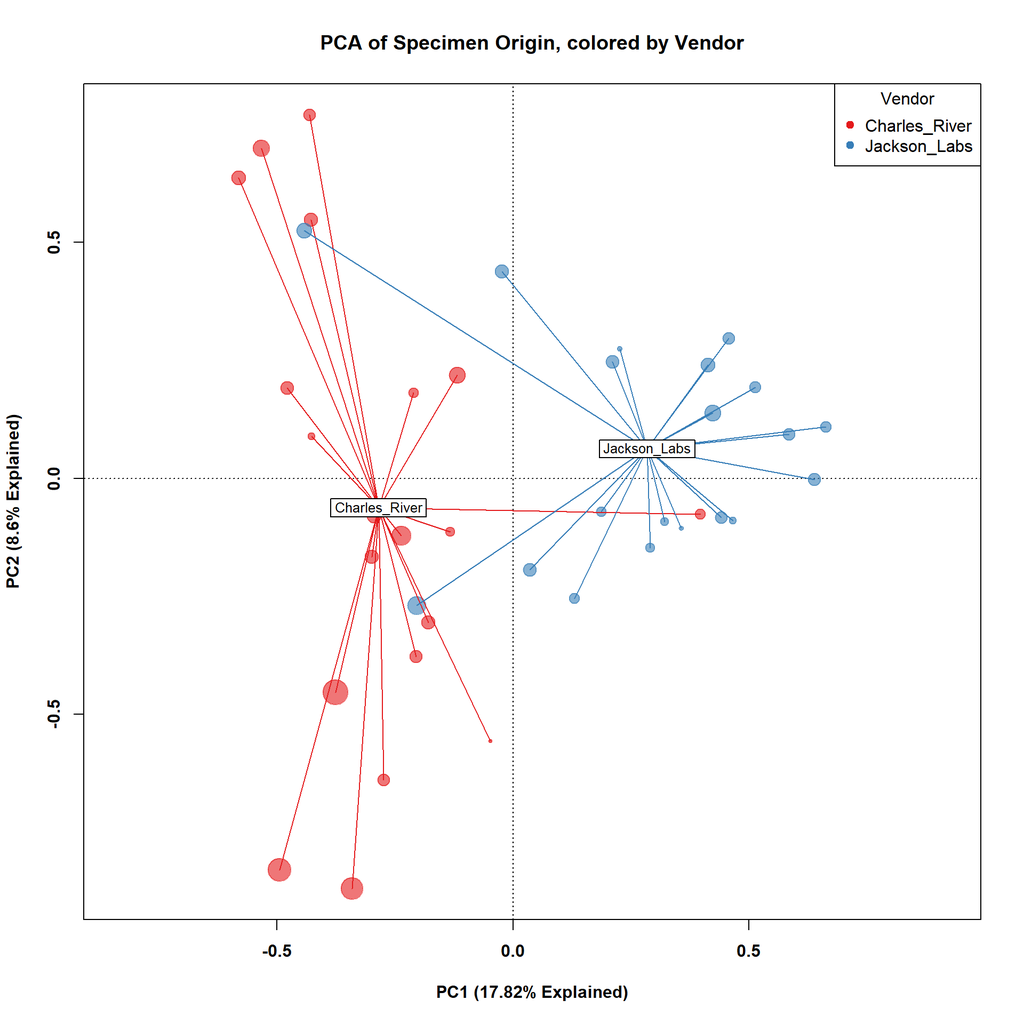

```r
# prepare x and y-axis labels
xlab = paste0("PC1 (",round(otu_con_lung_pca$CA$eig[1]/sum(otu_con_lung_pca$CA$eig)*100,2),"% Explained)")
ylab = paste0("PC2 (",round(otu_con_lung_pca$CA$eig[2]/sum(otu_con_lung_pca$CA$eig)*100,2),"% Explained)")

# Now let's scale the point size by a quantitative measure (log_IL1a) and adjust the point opacity
plot(otu_lung_pca, type = "n", font = 2, font.lab = 2, xlab = xlab, ylab = ylab, main = "PCA of Specimen Origin, colored by Vendor", display = "sites")
points(otu_lung_pca, pch = 19, col = alpha(pcapal[as.numeric(otu_lung_df$vendor)], 0.6), cex = 2*otu_lung_df$log_IL1a) # Note the use of alpha around the color vector and cex for the size. The size scale is doubled to make differences more apparent.
ordispider(otu_lung_pca, otu_lung_df$vendor, label = TRUE,  show.groups = c("Charles_River", "Jackson_Labs"), col = pcapal[c(1,2)]) # Draw lines from centroids to respective group's points.
legend("topright", levels(otu_lung_df$vendor), pch = 19, col = pcapal, title = "Vendor") # Format and add details to legends
```

#### 9.1.1.b Plotting other Principal Components

Suppose we want to examine PC1 and PC3 instead of PC1 and PC2. The `choices` parameter allows us to select PCs besides the PC1 and PC2 defaults. We’ll also need to update the axis labels accordingly.

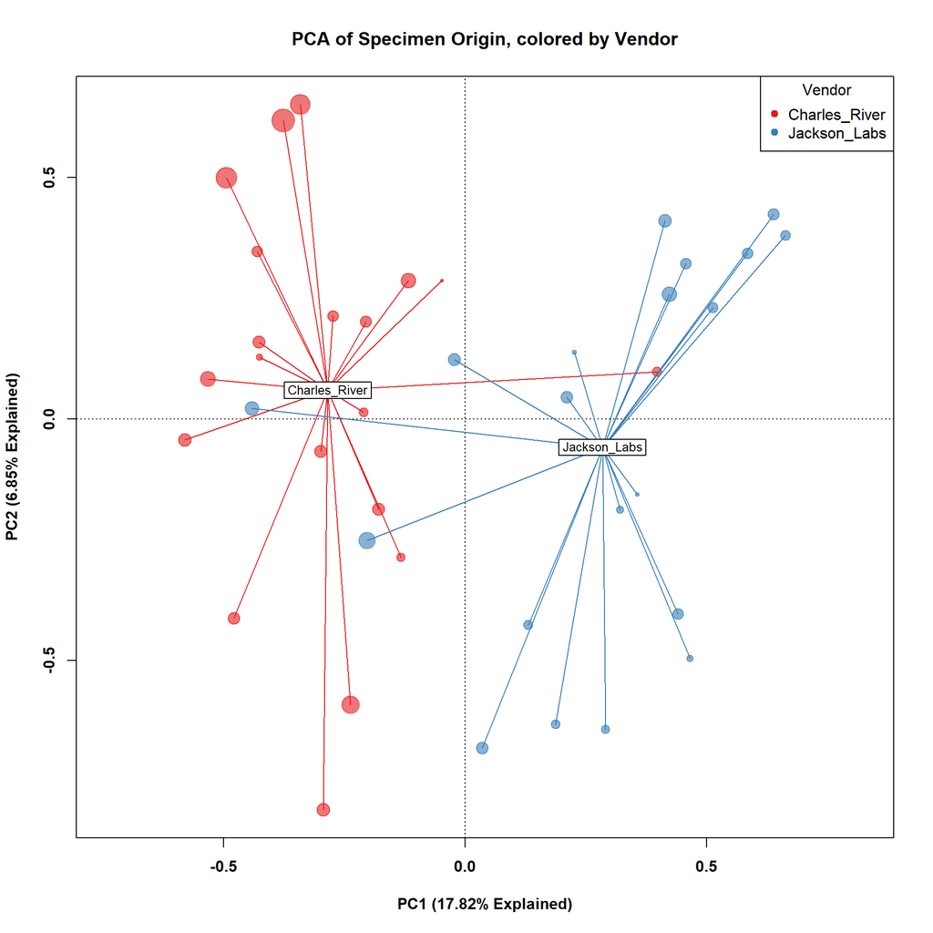

```r
# This approach combines base R plotting functionality and vegan's ordispider function, which creates the lines connecting points to the centroids.
# Unlike with ggplot(), these lines must all be run at once in order to produce the desired result.

# revise y-axis label
ylab = paste0("PC2 (",round(otu_con_lung_pca$CA$eig[3]/sum(otu_con_lung_pca$CA$eig)*100,2),"% Explained)")

plot(otu_lung_pca, choices = c(1,3), type = "n", font = 2, font.lab = 2, xlab = xlab, ylab = ylab, main = "PCA of Specimen Origin, colored by Vendor", display = "sites")
points(otu_lung_pca, choices = c(1,3), pch = 19, col = alpha(pcapal[as.numeric(otu_lung_df$vendor)], 0.6), cex = 2*otu_lung_df$log_IL1a) # Note the use of alpha around the color vector and cex for the size. The size scale is doubled to make differences more apparent.
ordispider(otu_lung_pca, choices = c(1,3), otu_lung_df$vendor, label = TRUE,  show.groups = c("Charles_River", "Jackson_Labs"), col = pcapal[c(1,2)]) # Draw lines from centroids to respective group's points.
legend("topright", levels(otu_lung_df$vendor), pch = 19, col = pcapal, title = "Vendor") # Format and add details to legends
```

### 9.1.2 Rank Abundance

#### 9.1.2.a Stacked Bar examples

Stacked bars also allow us to view trends across samples, at the cost of potentially making it more difficult to clearly measure differences in OTUs. There are several strategies to consider when creating such a visualization. Sometimes, when there are many OTUs within a taxonomic level, it may be of interest to combine levels or combine groups of related OTUs to avoid hundreds of very small lines on the resulting bars. This improves the overall visual clarity, though there should be a compelling reason for performing the grouping operation. Additionally, just as in the Rank Abundance visualizations we’ve already seen, how categories (OTUs or otherwise) are ordered is an important component in clearly presenting one’s results.

A basic example that requires no additional processing, can be constructed using `Phylum`, given that `g_df` already has this column thanks to our prior data preparation. The following visualization allows us to see broad trends and outliers in the relative abundance of various phyla across the samples.

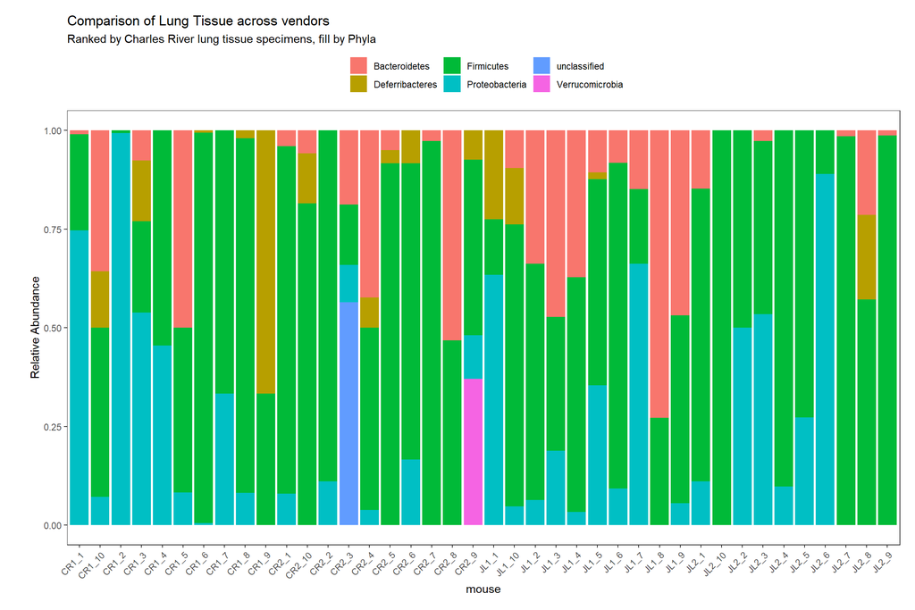

```r
# Stacked bar example (Phyla) by Mouse
ggplot(g_df, aes(x = mouse, y = Percentage, fill = Phylum)) +
  geom_bar(position = "fill", stat = "identity") +
  theme_bw() +
  theme(panel.grid = element_blank(), axis.text.x = element_text(angle = 45, hjust = 1), legend.position = "top", plot.margin = unit(c(0.5,0.5,0.5,1),"cm"),
        legend.title = element_blank()) +
  labs(title="Comparison of Lung Tissue across vendors", subtitle = "Ranked by Charles River lung tissue specimens, fill by Phyla", y = "Relative Abundance")
```

What would happen if we used the OTU column to fill corresponding portions of the bars? Note that because we’ve excluded all but the top 20 OTUs, the `position` parameter needs to changed from what was used in the Phyla visualization. Without changing this parameter, the implication is that these 20 OTUs comprise 100% of the data, which is not true.

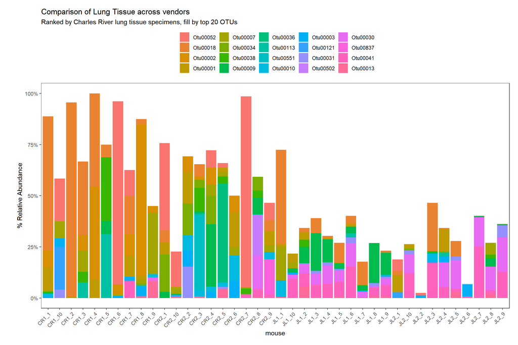

```r
# Stacked bar example (OTU) by Mouse
ggplot(g_df, aes(x = mouse, y = Percentage, fill = OTU)) +
  geom_bar(position = "stack", stat = "identity") + # Note parameter adjustment
  theme_bw() +
  theme(panel.grid = element_blank(), axis.text.x = element_text(angle = 45, hjust = 1), legend.position = "top", plot.margin = unit(c(0.5,0.5,0.5,1),"cm"),
        legend.title = element_blank()) +
  scale_y_continuous(labels = unit_format(suffix = "%")) +
  labs(title="Comparison of Lung Tissue across vendors", subtitle = "Ranked by Charles River lung tissue specimens, fill by top 20 OTUs", y = "% Relative Abundance")
```

Suppose we didn’t care for the white space, which represents the abundance of OTUs outside the top 20. All of the OTU data could be shown instead. In this case, careful consideration needs to be given for how to effectively represent the results. It’s clear that showing hundreds or thousands of OTUs in a single bar is not practical, and may also distract from other signals. Additionally, including hundreds of OTUs in a legend creates a plot that becomes difficult to examine (expanding the `fig.height` and `fig.width` parameters in the respective code chunk label can help). Most likely, many of the OTUs will need to be collapsed into an ‘Other’ category, or into related groups. The next code chunk contains an example of this, along with additional visual aesthetic modifications.

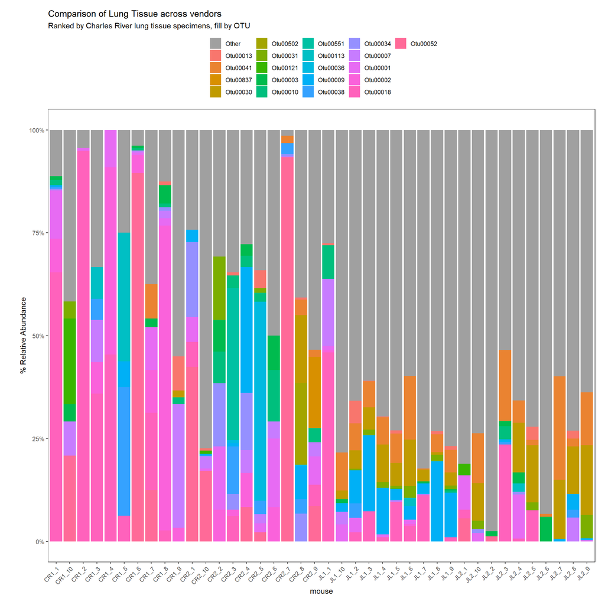

```r
# reprocess the data to retain all OTUs by keeping the entire otu_order vector
g_df_redux <- ra_df %>%
  dplyr::select(str_which(colnames(ra_df), "Otu", negate = TRUE), colnames(ra_df[, otu_order])) %>% # Keep non-OTU columns, followed by the OTUs in order of abundance
  pivot_longer(cols = -str_which(colnames(ra_df), "Otu", negate = TRUE), names_to = "OTU", values_to = "Percentage",
               names_ptypes = list(OTU = factor(levels = otu_order))) # Ensure OTU column is a factor is important due to the ordering expected in RA plots

g_df_redux$OTU <- g_df_redux$OTU %>%
  fct_relabel(~ case_when(.x %in% otu_order[1:20] ~ .x, # Retain the top 20 as independent levels
                          TRUE ~ "Other"), levels = c(otu_order[1:20], "Other")) # Any OTU besides the top 20 becomes 'Other'

# Sort the data by the factor used for fill to obtain desired appearance. This can take some experimentation to achieve optimal results.
g_df_redux <- g_df_redux %>%
  arrange(OTU)

# Stacked bar example (OTU) by Mouse
ggplot(g_df_redux, aes(x = mouse, y = Percentage, fill = fct_rev(OTU))) +
  geom_bar(position = "stack", stat = "identity") +
  theme_bw() +
  theme(panel.grid = element_blank(), axis.text.x = element_text(angle = 45, hjust = 1), legend.position = "top", plot.margin = unit(c(0.5,0.5,0.5,1),"cm"),
        legend.title = element_blank()) +
  scale_y_continuous(labels = unit_format(suffix = "%")) +
  labs(title="Comparison of Lung Tissue across vendors", subtitle = "Ranked by Charles River lung tissue specimens, fill by OTU", y = "% Relative Abundance") +
  scale_fill_manual(values = c("#A0A0A0", hue_pal()(20))) # Former is hexcode for a grey shade
```

### 9.1.3 Heatmaps

Next we’ll examine two approaches to constructing heat maps, using lung specimens.

#### 9.1.3.a ggplot implementation

If you’re comfortable with the `ggplot` approach to creating visualizations, you’ll likely be able to more easily customize these plots to your liking.

```r
# Determine the order of OTUs based on means within Lung specimens
otu_order <- names(sort(colMeans(otu_lung_df[, stringr::str_detect(colnames(otu_lung_df), "Otu")]), decreasing = TRUE))

heat_df <- otu_lung_df %>%
  dplyr::select(specimen, log_IL1a, otu_order[1:20]) %>% # Select the top 20 OTUs
  pivot_longer(cols = -c("specimen", "log_IL1a"), names_to = "OTU", values_to = "Percentage", # Pivots (longer) all columns expect those specified by -str_which()
               names_ptypes = list(OTU = factor(levels = otu_order[1:20])))

# Add Genus levels to the OTU Number
levels(heat_df$OTU) <- fct_inorder(paste0(otu_good_taxonomy[levels(heat_df$OTU), ]$Genus, " (", levels(heat_df$OTU), ")"))
```

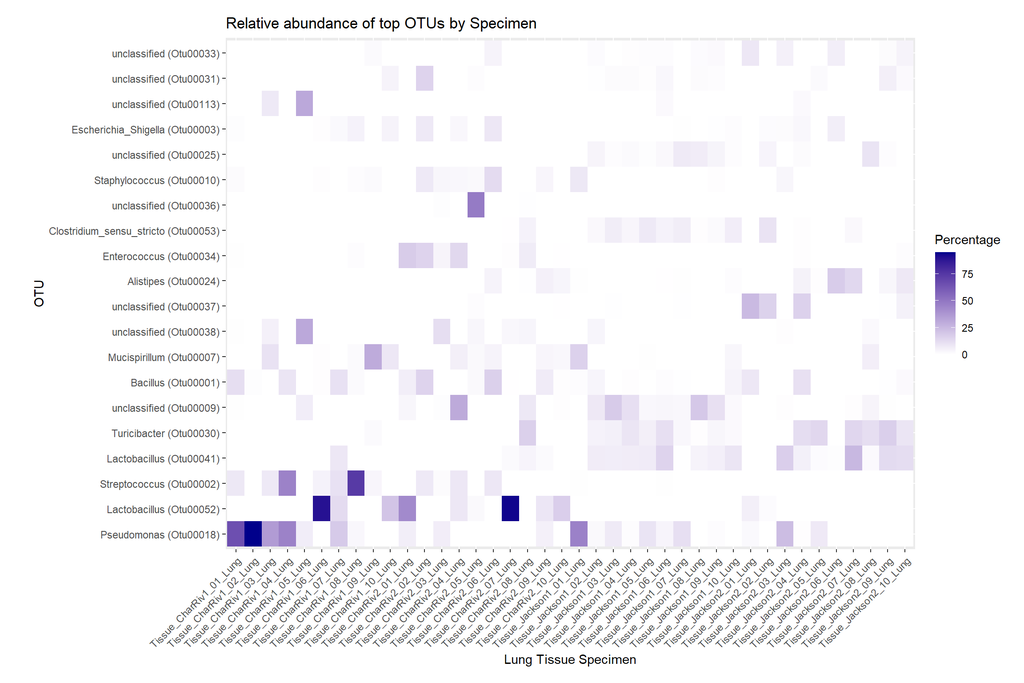

```r
# Note that the OTU levels are sorted in reverse order of abundance here - we could adjust this if desired.
ggplot(heat_df, aes(x = specimen, y = OTU)) +
  geom_tile(aes(fill = Percentage)) +
  theme(axis.text.x = element_text(angle = 45, hjust = 1), plot.margin = unit(c(0.5,0.5,0.5,1),"cm")) + # Extra plot padding is necessary due to the rotation of x-axis labels.
  scale_fill_gradient(low = "white", high = "dark blue") + # This allows us to specify the colors used within the heatmap
  labs(title = "Relative abundance of top OTUs by Specimen", x = "Lung Tissue Specimen")
```

#### 9.1.3.b Base R implementation & dendrogram

Next, we’ll explore a different approach using base R functionality. This time we’ll use dissimilarity data and construct dendrograms to go with the plot.

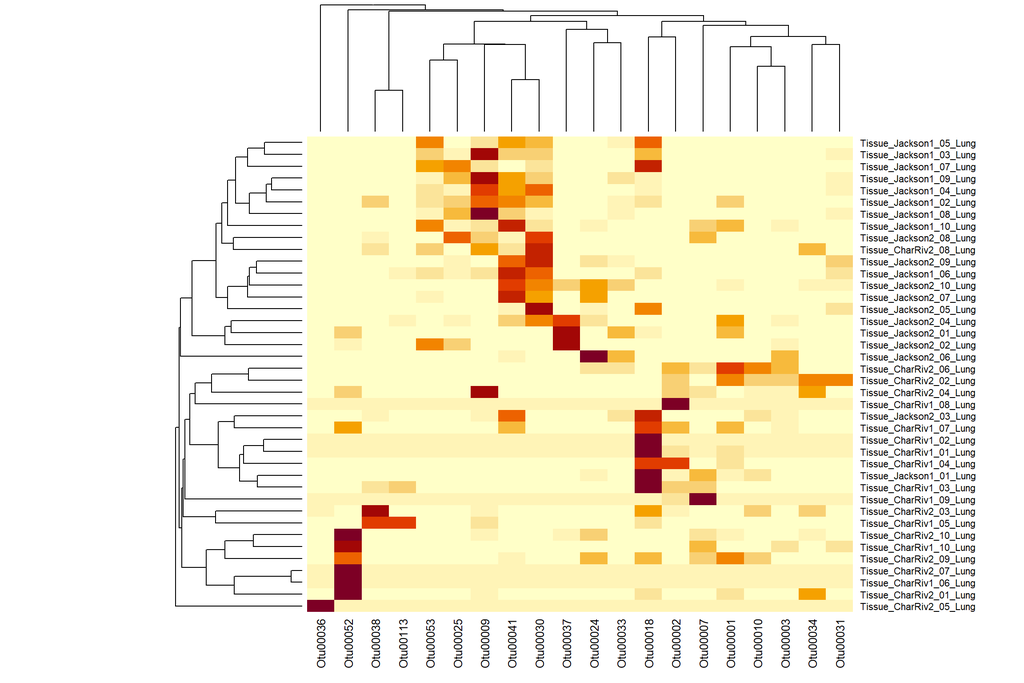

```r
# Unfortunately, filtering and other tidyverse functions strip rownames, and rownames are useful for pulling information out of matrices.
# However, there is a function to easily put the specimen column back into rownames
heat_df <- dplyr::filter(otu_df, tissue_type == "Lung") %>%
  droplevels() %>%
  remove_rownames() %>%
  column_to_rownames("specimen") %>% # This turns the specimen column into the rownames.
  dplyr::select(otu_order[1:20]) # Keep only the top 20 OTUs.

# Create Bray-Curtis matrix for lung specimens
bc_lung_spec <- vegan::vegdist(dplyr::select(heat_df, otu_order[1:20]), method = "bray")
# The linkage method to be used will depend on the nature of the data
clust_lung_spec <- hclust(bc_lung_spec, method = "average")

# Create Bray-Curtis matrix for OTUs
bc_lung_otu <- vegan::vegdist(t(dplyr::select(heat_df, otu_order[1:20])), method = "bray")
clust_lung_otu <- hclust(bc_lung_otu, method = "average")

# Create the heatmap with dendrograms
heatmap(as.matrix(dplyr::select(heat_df, str_which(colnames(heat_df), "Otu"))), Rowv = as.dendrogram(clust_lung_spec),
        Colv = as.dendrogram(clust_lung_otu), margins=c(5,0))
```

## 9.2 Relative Abundance of Key Community Members

### 9.2.1 Random Forests

#### 9.2.1.a Regression

With a few minor tweaks to the prior classification forest code for data preparation, retrieval, and plotting, we’ll demonstrate how to retrieve feature importances from a collection of random forest regression models. In this example, we’ll use log_IL1a as the response variable.

```r
# For lung specimens, retain only log_IL1a & OTU columns
rf_reg_df <- dplyr::filter(fam_df, tissue_type == "Lung") %>%
  dplyr::select(log_IL1a, levels(otu_good_taxonomy$Family)) %>%
  droplevels()

a <- Sys.time()
nforest <- 100
set.seed(rnd_seed) # seed for reproducibility
rf_reg_list <- vector("list", nforest) # Initialize a list to store the randomForests
for (i in seq_along(1:nforest)) { # Loops nforest number of times, creating a model and saving it into the list each time.
    rf_reg_list[[i]] <- randomForest(log_IL1a ~ ., data = rf_reg_df, importance = TRUE)
}
b <- Sys.time()
b-a
```

```
## Time difference of 5.480302 secs
```

```r
# Extract the feature importances
reg_fi_df <- purrr::map(rf_reg_list, ~{.[["importance"]][, 1]}) %>% # 1 specified the index of the importance column (%IncMSE - regression)
  unlist() %>%
  data.frame(Feature = names(.), X.IncMSE = .)

meas <- colnames(reg_fi_df)[2] # "X.IncMSE"

# Identify the top features
top_feat <- reg_fi_df %>%
  dplyr::group_by(Feature) %>%
  summarize(`:=`(!!meas, mean(.data[[meas]])), .groups = "drop") %>%
  arrange(desc(.data[[meas]])) %>%
  head(20) %>% # Top 20 features
  droplevels()

# Retain only the top features
reg_fi_df <- dplyr::filter(reg_fi_df, Feature %in% top_feat$Feature) %>%
  droplevels() %>%
  rename(IncMSE=X.IncMSE)
reg_fi_df$Feature <- forcats::fct_reorder(reg_fi_df$Feature, reg_fi_df[, 2], .fun = mean, .desc = TRUE)
```

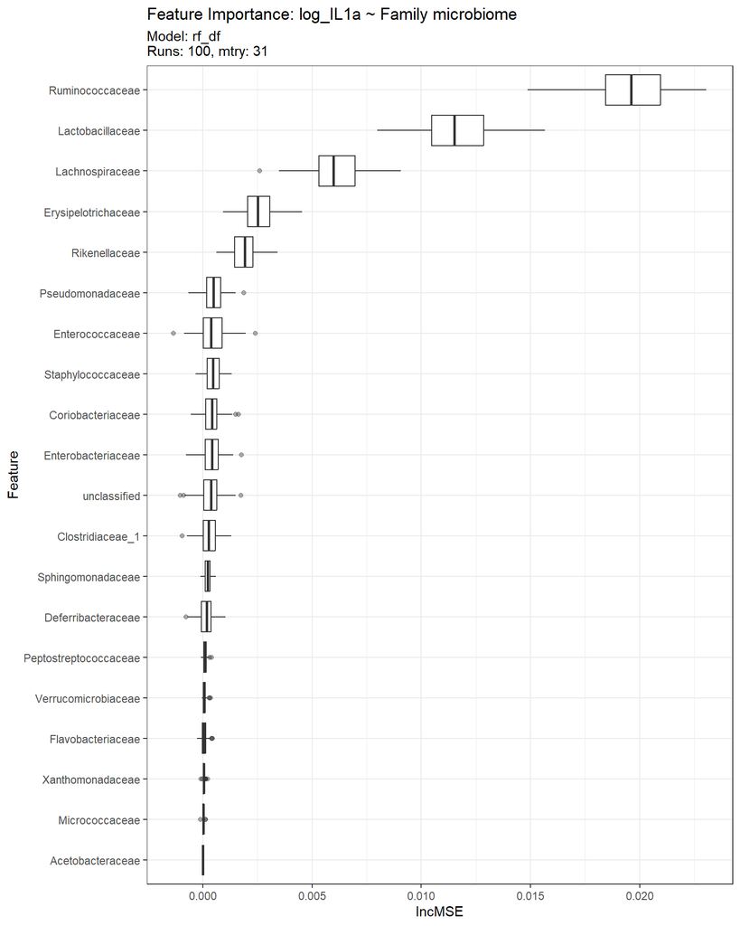

```r
ggplot(reg_fi_df, aes(x = Feature, y = reg_fi_df[, 2])) +
  geom_boxplot(outlier.alpha = 0.4) +
  theme_bw() +
  labs(y = "IncMSE", title = paste0("Feature Importance: log_IL1a ~ Family microbiome"),
       subtitle = paste0("Model: rf_df \nRuns: ", length(rf_reg_list), ", mtry: ", rf_reg_list[[1]]$mtry)) +
  coord_flip() + # Flip the axes for improved readability
  scale_x_discrete(limits = rev(levels(reg_fi_df$Feature)))
```